# Ford GoBike System Data Exploration

## Preliminary Wrangling

> This document explores a dataset containing information about individual rides made in a bike-sharing system covering the greater San Francisco Bay area.

```python
# import all packages and set plots to be embedded inline
import numpy as np
import pandas as pd
import matplotlib.pyplot as plt
import seaborn as sb

%matplotlib inline
```

```python
# load in the dataset into a pandas dataframe
rides = pd.read_csv('2017-fordgobike-tripdata.csv')
```

```python
#overview of data shape and composition
rides.shape
```

```
(519700, 15)
```

```python
rides.head()
```

|  | duration_sec | start_time | end_time | start_station_id | start_station_name | start_station_latitude | start_station_longitude | end_station_id | end_station_name | end_station_latitude | end_station_longitude | bike_id | user_type | member_birth_year | member_gender |
| --- | --- | --- | --- | --- | --- | --- | --- | --- | --- | --- | --- | --- | --- | --- | --- |
| 0 | 80110 | 2017-12-31 16:57:39.6540 | 2018-01-01 15:12:50.2450 | 74 | Laguna St at Hayes St | 37.776435 | -122.426244 | 43 | San Francisco Public Library (Grove St at Hyde... | 37.778768 | -122.415929 | 96 | Customer | 1987.0 | Male |
| 1 | 78800 | 2017-12-31 15:56:34.8420 | 2018-01-01 13:49:55.6170 | 284 | Yerba Buena Center for the Arts (Howard St at ... | 37.784872 | -122.400876 | 96 | Dolores St at 15th St | 37.766210 | -122.426614 | 88 | Customer | 1965.0 | Female |
| 2 | 45768 | 2017-12-31 22:45:48.4110 | 2018-01-01 11:28:36.8830 | 245 | Downtown Berkeley BART | 37.870348 | -122.267764 | 245 | Downtown Berkeley BART | 37.870348 | -122.267764 | 1094 | Customer | NaN | NaN |
| 3 | 62172 | 2017-12-31 17:31:10.6360 | 2018-01-01 10:47:23.5310 | 60 | 8th St at Ringold St | 37.774520 | -122.409449 | 5 | Powell St BART Station (Market St at 5th St) | 37.783899 | -122.408445 | 2831 | Customer | NaN | NaN |
| 4 | 43603 | 2017-12-31 14:23:14.0010 | 2018-01-01 02:29:57.5710 | 239 | Bancroft Way at Telegraph Ave | 37.868813 | -122.258764 | 247 | Fulton St at Bancroft Way | 37.867789 | -122.265896 | 3167 | Subscriber | 1997.0 | Female |

```python
rides.info()
```

```
<class 'pandas.core.frame.DataFrame'>
RangeIndex: 519700 entries, 0 to 519699
Data columns (total 15 columns):
duration_sec               519700 non-null int64
start_time                 519700 non-null object
end_time                   519700 non-null object
start_station_id           519700 non-null int64
start_station_name         519700 non-null object
start_station_latitude     519700 non-null float64
start_station_longitude    519700 non-null float64
end_station_id             519700 non-null int64
end_station_name           519700 non-null object
end_station_latitude       519700 non-null float64
end_station_longitude      519700 non-null float64
bike_id                    519700 non-null int64
user_type                  519700 non-null object
member_birth_year          453159 non-null float64
member_gender              453238 non-null object
dtypes: float64(5), int64(4), object(6)
memory usage: 59.5+ MB
```

```python
#Convert columns to an appropriate type
rides['start_time'] = pd.to_datetime(rides.start_time)
rides['end_time'] = pd.to_datetime(rides.end_time)
rides['start_station_id'] = rides['start_station_id'].astype(object)
rides['end_station_id'] = rides['end_station_id'].astype(object)
rides['bike_id'] = rides['bike_id'].astype(object)
rides['member_birth_year'] = rides['member_birth_year'].fillna(0).astype(int)
```

```python
rides.describe()
```

|  | duration_sec | start_station_latitude | start_station_longitude | end_station_latitude | end_station_longitude | member_birth_year |
| --- | --- | --- | --- | --- | --- | --- |
| count | 519700.000000 | 519700.000000 | 519700.000000 | 519700.000000 | 519700.000000 | 519700.000000 |
| mean | 1099.009521 | 37.771653 | -122.363927 | 37.771844 | -122.363236 | 1726.839048 |
| std | 3444.146451 | 0.086305 | 0.105573 | 0.086224 | 0.105122 | 661.788821 |
| min | 61.000000 | 37.317298 | -122.444293 | 37.317298 | -122.444293 | 0.000000 |
| 25% | 382.000000 | 37.773492 | -122.411726 | 37.774520 | -122.410345 | 1968.000000 |
| 50% | 596.000000 | 37.783521 | -122.398870 | 37.783830 | -122.398525 | 1981.000000 |
| 75% | 938.000000 | 37.795392 | -122.391034 | 37.795392 | -122.391034 | 1987.000000 |
| max | 86369.000000 | 37.880222 | -121.874119 | 37.880222 | -121.874119 | 1999.000000 |

### What is the structure of your dataset?

> There are 519,700 rides in the dataset with 15 features, such as: (bike_id, user_type, member_gender ... etc). Most variables are numeric in nature.

### What is/are the main feature(s) of interest in your dataset?

> I'm most interested in figuring out the effect that have been made by some features on the dataset, such as Genders and Average riding duration.

### What features in the dataset do you think will help support your investigation into your feature(s) of interest?

> Duration seconds, Start Time , End Time , User Type , Member Birth Year , Member Gender.

## Univariate Exploration

```python
rides['bike_id'].sum()
```

```
869215441
```

### How does the rides trend change per gender, weekday, and hour of a day?

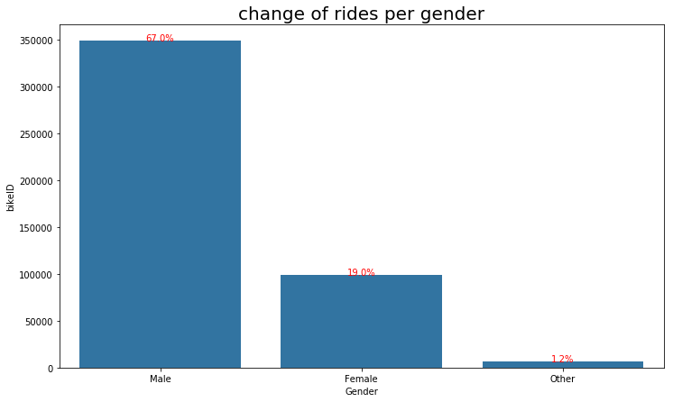

```python
base_color = sb.color_palette()[0]
plt.figure(figsize=(12,7))
sb.countplot(data = rides, x = 'member_gender', color = base_color)

n_points = rides.shape[0]
cat_counts = rides['member_gender'].value_counts();
locs, labels = plt.xticks();

for loc, label in zip(locs, labels):

    count = cat_counts[label.get_text()]
    pct_string = '{:0.1f}%'.format(100*count/n_points)
    plt.text(loc, count-8, pct_string, ha = 'center', color = 'r')


plt.title('change of rides per gender', fontsize=20)
plt.xlabel('Gender')
plt.ylabel('bikeID')
plt.show()
```

we can observe that Number of rides that have been ridden by male are more than rides that rides that have been ridden by female.

```python
import calendar
rides['start_time_DAY']=rides['start_time'].dt.weekday.apply(lambda x: calendar.day_abbr[x])
```

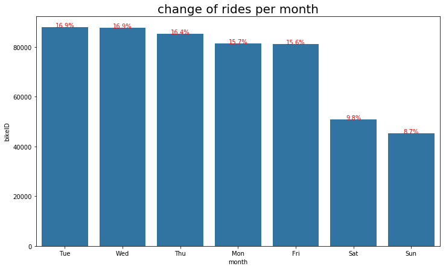

```python
base_color = sb.color_palette()[0]
dayscount= rides['start_time_DAY'].value_counts()
orderr =dayscount.index
plt.figure(figsize=(12,7))
sb.countplot(data = rides, x = 'start_time_DAY', color = base_color, order = orderr )

n_points = rides.shape[0]
cat_counts = rides['start_time_DAY'].value_counts();
locs, labels = plt.xticks();

for loc, label in zip(locs, labels):

    count = cat_counts[label.get_text()]
    pct_string = '{:0.1f}%'.format(100*count/n_points)
    plt.text(loc, count-8, pct_string, ha = 'center', color = 'r')


plt.title('change of rides per month', fontsize=20)
plt.xlabel('month')
plt.ylabel('bikeID')
plt.show()
```

we can observe that Number of rides seem to be decrease at weekend days, unlike weekdays.

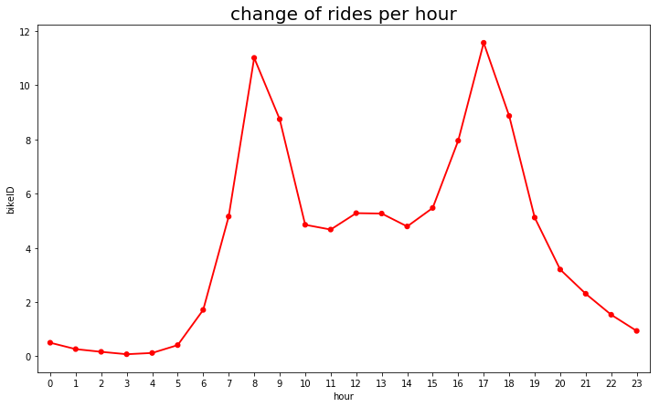

```python
rides['start_time_hour']=rides['start_time'].dt.hour
hour_df = rides.groupby('start_time_hour').agg({'bike_id':'count'}).reset_index()
hour_df['bike_id'] = (hour_df['bike_id']/hour_df['bike_id'].sum())*100
plt.figure(figsize=(12,7))
sb.pointplot(x='start_time_hour', y='bike_id', scale=.7, color='red', data=hour_df)


plt.title('change of rides per hour', fontsize=20)
plt.xlabel('hour')
plt.ylabel('bikeID')
plt.show()
```

we can observe that Number of rides are increase two times a day, 8am and 5pm.

### Of the features you investigated, were there any unusual distributions? Did you perform any operations on the data to tidy, adjust, or change the form of the data? If so, why did you do this?

> Yes, I create two new varibles in the dataframe (start_time_hour , start_time_DAY), to help me in my investigation so i can easily see the trend per day and per each hour on the day.

## Bivariate Exploration

### Does the month have any effect on the duration of the rides?

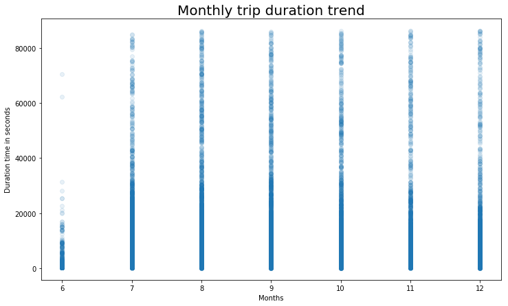

```python
plt.figure(figsize = [12,7])
rides['start_time_month']=rides['start_time'].dt.month.astype(int)
plt.scatter(data = rides , x = 'start_time_month' , y = 'duration_sec' , alpha = 0.1 )


plt.title('Monthly trip duration trend', fontsize=20)
plt.xlabel('Months')
plt.ylabel('Duration time in seconds')
plt.show()
```

```python
rides['month_start'].value_counts()
```

```
10    108937
9      98558
11     95612
12     86539
8      83292
7      44073
6       2689
Name: month_start, dtype: int64
```

### Is there any diffrence between the rides of subscriber and the rides of customer each month?

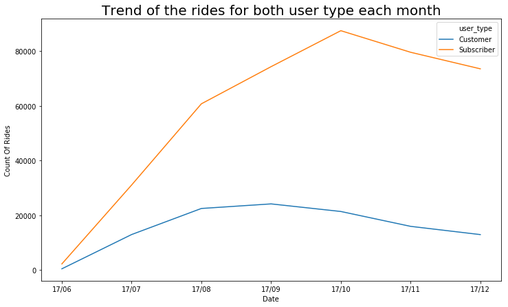

```python
rides['start_time_date']=rides['start_time'].dt.strftime('%y' + '/' + '%m')
user_type_date = rides.groupby(["start_time_date", "user_type"]).size().reset_index()
plt.figure(figsize=(12,7))
sb.lineplot(x='start_time_date',y=0, hue='user_type', data=user_type_date)


plt.title('Trend of the rides for both user type each month', fontsize=20)
plt.xlabel('Date')
plt.ylabel('Count Of Rides')
plt.show()
```

we can observe that there is a huge diffrence between the increasing of customer rides and subscriber rides.

## Multivariate Exploration

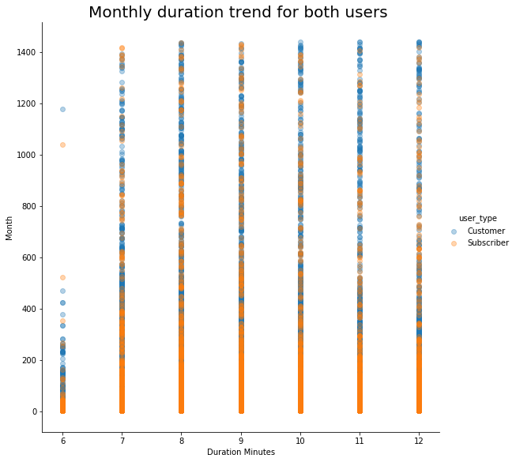

```python
rides['duration_min'] = rides['duration_sec'] / 60
plt.figure(figsize = [20,20])
g = sb.FacetGrid(data =  rides, hue = 'user_type', height = 8)
g.map(plt.scatter, 'month_start','duration_min', alpha = 1/3)
g.add_legend()

plt.title('Monthly duration trend for both users ', fontsize=20)
plt.xlabel('Duration Minutes')
plt.ylabel('Month')
plt.show()
```

we can observe that subscriber user usually tend to take less than customer user trip duration.

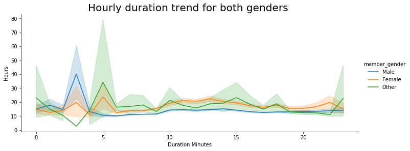

```python
plt.figure(figsize = [20,20])
g = sb.FacetGrid(data =  rides, hue = 'member_gender', size = 4, aspect= 2.5)
g = g.map(sb.lineplot, 'start_time_hour','duration_min')
g.add_legend()


plt.title('Hourly duration trend for both genders ', fontsize=20)
plt.xlabel('Duration Minutes')
plt.ylabel('Hours')
plt.show()
```